# Biochar for sustainable agriculture: Prospects and implications - ScienceDirect

[figure not shown]

## Figures (3)

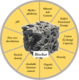

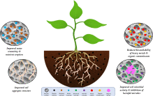

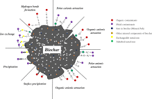

[figure not shown]

## [Advances in Chemical Pollution, Environmental Management and Protection](https://www.sciencedirect.com/bookseries/advances-in-chemical-pollution-environmental-management-and-protection)

[Volume 7](https://www.sciencedirect.com/bookseries/advances-in-chemical-pollution-environmental-management-and-protection/vol/7/suppl/C), 2021, Pages 221-262

# Chapter Nine - Biochar for sustainable agriculture: Prospects and implications

https://doi.org/10.1016/bs.apmp.2021.08.008[Get rights and content](https://s100.copyright.com/AppDispatchServlet?publisherName=ELS&contentID=S2468928921000083&orderBeanReset=true)

## Abstract

Biochar application in soil can play a substantial part in altering the soil nutrients dynamics, pollutants, and microbial ecology. Also, strategic biochar treatments in soil may promote sustainable agriculture while providing numerous agronomic, economic, and environmental benefits. Both physical characteristics of biochar including surface area, particle density, and pore size distribution, and chemical characteristics like pH, electrical conductivity, total and plant-available concentrations of carbon, nitrogen, potassium, and phosphorus, cation exchange capacity, and selected minor nutrient contents influence its agronomic potential in soil. Some of the key outputs of biochar amendment include better nutrient management in soil, improved crop growth and productivity, enhanced crop physiological parameters and quality, reduced bioavailability of contaminants in soil and overall decrease in greenhouse gas emissions from soil. Moreover, the associated benefits of carbon sequestration through its highly recalcitrant nature could aid in the mitigation of climate change. The economic benefits of improved crop yield along with reduced costs of frequent fertilizers application and reduced irrigation can help in achieving economic stability and profitability to the farmers without compromising the preservation of environmental ecosystems. However, since most of these effects of biochar are highly dependent on variable factors including soil type, crop type and agroclimatic conditions, etc., long term field investigations focussing on positive and negative implications and potential limitations are necessary to propose biochar for practical agricultural applications.

## Keywords

Biochar

Agriculture

Soil amendment

Carbon sequestration

Nutrient dynamics

Crop productivity

Copyright © 2021 Elsevier Inc. All rights reserved.

## Part of volume:

[Biochar: Fundamentals and Applications in Environmental Science and Remediation Technologies](https://www.sciencedirect.com/science/journal/24689289/7/supp/C)

Edited by

Ajit K. Sarmah

[figure not shown]

[figure not shown]